# Kaggle_Spaceship_Classifier_Template

```python
# Regular EDA (exploratory data analysis) and plotting libraries
import numpy as np # np is short for numpy
import pandas as pd # pandas is so commonly used, it's shortened to pd
import matplotlib.pyplot as plt
import seaborn as sns

# We want our plots to appear in the notebook
%matplotlib inline

## Models
from sklearn.linear_model import LogisticRegression
from sklearn.neighbors import KNeighborsClassifier
from sklearn.ensemble import RandomForestClassifier
from sklearn.ensemble import ExtraTreesClassifier
from sklearn.ensemble import HistGradientBoostingClassifier
from sklearn.ensemble import AdaBoostClassifier

## Model evaluators
from sklearn.model_selection import train_test_split, cross_val_score
from sklearn.model_selection import RandomizedSearchCV, GridSearchCV
from sklearn.metrics import confusion_matrix, classification_report
from sklearn.metrics import precision_score, recall_score, f1_score
from sklearn.metrics import plot_roc_curve
from sklearn.metrics import ConfusionMatrixDisplay
from sklearn.metrics import RocCurveDisplay

import tensorflow as tf

# Import series of helper functions for the notebook (we've created/used these in previous notebooks)
from helper_functions import make_confusion_matrix, create_tensorboard_callback, plot_loss_curves, unzip_data, compare_historys, walk_through_dir

import xgboost as xgb

# Supposed to increase speed on Intel CPUs
from sklearnex import patch_sklearn, config_context
patch_sklearn()

# For timing cell execution
from timeit import default_timer as timer
from datetime import timedelta
```

```
2022-08-06 05:20:42.662261: I tensorflow/stream_executor/platform/default/dso_loader.cc:49] Successfully opened dynamic library libcudart.so.10.1
Intel(R) Extension for Scikit-learn* enabled (https://github.com/intel/scikit-learn-intelex)
```

```python
# Enable/Disable the long running models, **Choice must be mutually exclusive**

RUN_LR_RANDOM  = False    # LogisticRegression
RUN_LR_GRID    = False
RUN_RF_RANDOM  = False    # RandomForestClassifier
RUN_RF_GRID    = False
RUN_XGB_RANDOM = False    # XGBoostClassifier
RUN_XGB_GRID   = False
RUN_ET_RANDOM  = False    # ExtraTreesClassifier
RUN_ET_GRID    = False
RUN_AB_RANDOM  = False    # AdaBoostClassifier
RUN_AB_GRID    = False
RUN_HGB_RANDOM = False    # HistGradientBoostingClassifier
RUN_HGB_GRID   = True
```

```python
# Should all the numerical data be normalized to a value between 0 and 1?
NORMALIZE_DATA = False

# Not normalizing the data helped the HistGradientBoosting model quite a bit.
```

```python
def prepare_kaggle_submission(clf, processed_test_data, test_data, model_str):
    """
    Prepares the CSV file for Kaggle competition submission
    """
    predictions = clf.predict(processed_test_data)
    predictions = np.squeeze(predictions)
    predictions = np.where(predictions > 0.5, True, False)

    output = pd.DataFrame({'PassengerId': test_data.PassengerId, 'Transported': predictions})
    print (output)

    output.to_csv('submission_' + model_str + '.csv', index=False)
```

## Import the Training and Validation Data

```python
train_valid_data = pd.read_csv("data/train.csv")
train_valid_data.shape
```

```
(8693, 14)
```

```python
train_valid_data.head()
```

|  | PassengerId | HomePlanet | CryoSleep | Cabin | Destination | Age | VIP | RoomService | FoodCourt | ShoppingMall | Spa | VRDeck | Name | Transported |
| --- | --- | --- | --- | --- | --- | --- | --- | --- | --- | --- | --- | --- | --- | --- |
| 0 | 0001_01 | Europa | False | B/0/P | TRAPPIST-1e | 39.0 | False | 0.0 | 0.0 | 0.0 | 0.0 | 0.0 | Maham Ofracculy | False |
| 1 | 0002_01 | Earth | False | F/0/S | TRAPPIST-1e | 24.0 | False | 109.0 | 9.0 | 25.0 | 549.0 | 44.0 | Juanna Vines | True |
| 2 | 0003_01 | Europa | False | A/0/S | TRAPPIST-1e | 58.0 | True | 43.0 | 3576.0 | 0.0 | 6715.0 | 49.0 | Altark Susent | False |
| 3 | 0003_02 | Europa | False | A/0/S | TRAPPIST-1e | 33.0 | False | 0.0 | 1283.0 | 371.0 | 3329.0 | 193.0 | Solam Susent | False |
| 4 | 0004_01 | Earth | False | F/1/S | TRAPPIST-1e | 16.0 | False | 303.0 | 70.0 | 151.0 | 565.0 | 2.0 | Willy Santantines | True |

## Import the Testing Data

```python
test_data = pd.read_csv("data/test.csv")
test_data.shape
```

```
(4277, 13)
```

```python
test_data.head()
```

|  | PassengerId | HomePlanet | CryoSleep | Cabin | Destination | Age | VIP | RoomService | FoodCourt | ShoppingMall | Spa | VRDeck | Name |
| --- | --- | --- | --- | --- | --- | --- | --- | --- | --- | --- | --- | --- | --- |
| 0 | 0013_01 | Earth | True | G/3/S | TRAPPIST-1e | 27.0 | False | 0.0 | 0.0 | 0.0 | 0.0 | 0.0 | Nelly Carsoning |
| 1 | 0018_01 | Earth | False | F/4/S | TRAPPIST-1e | 19.0 | False | 0.0 | 9.0 | 0.0 | 2823.0 | 0.0 | Lerome Peckers |
| 2 | 0019_01 | Europa | True | C/0/S | 55 Cancri e | 31.0 | False | 0.0 | 0.0 | 0.0 | 0.0 | 0.0 | Sabih Unhearfus |
| 3 | 0021_01 | Europa | False | C/1/S | TRAPPIST-1e | 38.0 | False | 0.0 | 6652.0 | 0.0 | 181.0 | 585.0 | Meratz Caltilter |
| 4 | 0023_01 | Earth | False | F/5/S | TRAPPIST-1e | 20.0 | False | 10.0 | 0.0 | 635.0 | 0.0 | 0.0 | Brence Harperez |

## Exploratory Data Analysis

```
(7.5, -0.5)
```

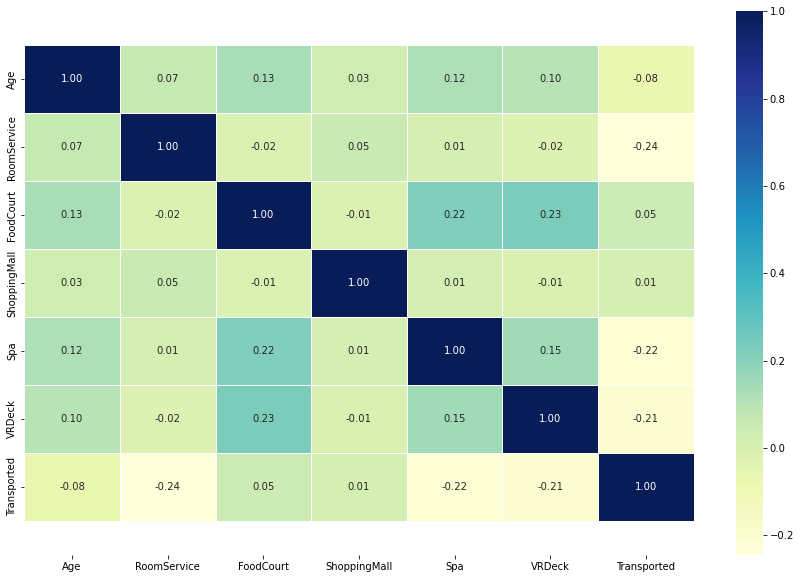

```python
# Create a correlation matrix for all the data
corr_matrix = train_valid_data.corr()
plt.figure(figsize=(15, 10))
ax = sns.heatmap(corr_matrix,
                 annot=True,
                 linewidths=0.5,
                 fmt= ".2f",
                 cmap="YlGnBu");

# fix display problems with first and last row getting cut off
bottom, top = ax.get_ylim()
ax.set_ylim(bottom + 0.5, top - 0.5)
```

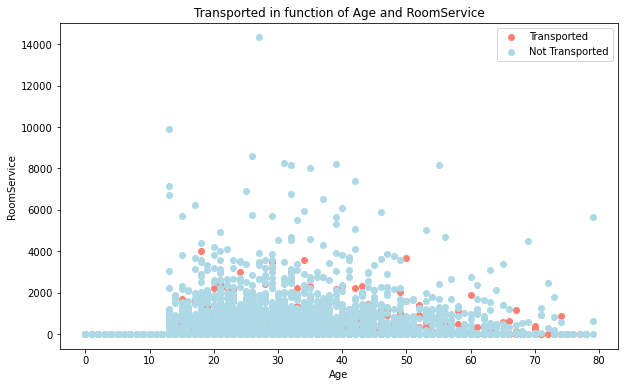

```python
# Create another figure
plt.figure(figsize=(10,6))

# Start with positve examples (get two independed variables where person was Transported)
plt.scatter(train_valid_data.Age[train_valid_data.Transported==1],
            train_valid_data.RoomService[train_valid_data.Transported==1],
            c="salmon") # define it as a scatter figure

# Now for negative examples, we want them on the same plot, so we call plt again
plt.scatter(train_valid_data.Age[train_valid_data.Transported==0],
            train_valid_data.RoomService[train_valid_data.Transported==0],
            c="lightblue") # axis always come as (x, y)

# Add some helpful info
plt.title("Transported in function of Age and RoomService")
plt.xlabel("Age")
plt.legend(["Transported", "Not Transported"])
plt.ylabel("RoomService");
```

[figure not shown]

```python
# Create a new crosstab and base plot
pd.crosstab(train_valid_data.CryoSleep, train_valid_data.Transported).plot(kind="bar",
                                                                     figsize=(10,6),
                                                                     color=["lightblue", "salmon"])

# Add attributes to the plot to make it more readable
plt.title("Transported Frequency Per Age")
plt.xlabel("CryoSleep")
plt.ylabel("Frequency")
plt.legend(["Not Transported", "Transported"])
plt.xticks(rotation = 0);
```

## Check for Missing Data in the Training & Validation Set

```python
train_valid_data.isna().sum()
```

```
PassengerId       0
HomePlanet      201
CryoSleep       217
Cabin           199
Destination     182
Age             179
VIP             203
RoomService     181
FoodCourt       183
ShoppingMall    208
Spa             183
VRDeck          188
Name            200
Transported       0
dtype: int64
```

## Check for Missing Data in the Test Set

```python
test_data.isna().sum()
```

```
PassengerId       0
HomePlanet       87
CryoSleep        93
Cabin           100
Destination      92
Age              91
VIP              93
RoomService      82
FoodCourt       106
ShoppingMall     98
Spa             101
VRDeck           80
Name             94
dtype: int64
```

## Preprocess the Training/Validation and Test Sets

> 1. Extract important features
> 2. Fill missing data
> 3. Normalize data

```python
processed_train_valid_data = train_valid_data.drop("Name", axis=1)
processed_train_valid_data.head()
```

|  | PassengerId | HomePlanet | CryoSleep | Cabin | Destination | Age | VIP | RoomService | FoodCourt | ShoppingMall | Spa | VRDeck | Transported |
| --- | --- | --- | --- | --- | --- | --- | --- | --- | --- | --- | --- | --- | --- |
| 0 | 0001_01 | Europa | False | B/0/P | TRAPPIST-1e | 39.0 | False | 0.0 | 0.0 | 0.0 | 0.0 | 0.0 | False |
| 1 | 0002_01 | Earth | False | F/0/S | TRAPPIST-1e | 24.0 | False | 109.0 | 9.0 | 25.0 | 549.0 | 44.0 | True |
| 2 | 0003_01 | Europa | False | A/0/S | TRAPPIST-1e | 58.0 | True | 43.0 | 3576.0 | 0.0 | 6715.0 | 49.0 | False |
| 3 | 0003_02 | Europa | False | A/0/S | TRAPPIST-1e | 33.0 | False | 0.0 | 1283.0 | 371.0 | 3329.0 | 193.0 | False |
| 4 | 0004_01 | Earth | False | F/1/S | TRAPPIST-1e | 16.0 | False | 303.0 | 70.0 | 151.0 | 565.0 | 2.0 | True |

```python
processed_test_data = test_data.drop("Name", axis=1)
processed_test_data.head()
```

|  | PassengerId | HomePlanet | CryoSleep | Cabin | Destination | Age | VIP | RoomService | FoodCourt | ShoppingMall | Spa | VRDeck |
| --- | --- | --- | --- | --- | --- | --- | --- | --- | --- | --- | --- | --- |
| 0 | 0013_01 | Earth | True | G/3/S | TRAPPIST-1e | 27.0 | False | 0.0 | 0.0 | 0.0 | 0.0 | 0.0 |
| 1 | 0018_01 | Earth | False | F/4/S | TRAPPIST-1e | 19.0 | False | 0.0 | 9.0 | 0.0 | 2823.0 | 0.0 |
| 2 | 0019_01 | Europa | True | C/0/S | 55 Cancri e | 31.0 | False | 0.0 | 0.0 | 0.0 | 0.0 | 0.0 |
| 3 | 0021_01 | Europa | False | C/1/S | TRAPPIST-1e | 38.0 | False | 0.0 | 6652.0 | 0.0 | 181.0 | 585.0 |
| 4 | 0023_01 | Earth | False | F/5/S | TRAPPIST-1e | 20.0 | False | 10.0 | 0.0 | 635.0 | 0.0 | 0.0 |

```python
# Fill missing HomePlanet data with "missing"
for label, content in processed_train_valid_data.items():
    if label=="HomePlanet":
        if pd.isnull(content).sum():
            processed_train_valid_data[label] = content.fillna("missing")

# Fill Age rows with the median if they are missing in the Test data set
for label, content in processed_test_data.items():
    if label=="HomePlanet":
        if pd.isnull(content).sum():
            processed_test_data[label] = content.fillna("missing")
```

```python
# Fill missing CryoSleep data with "missing"
for label, content in processed_train_valid_data.items():
    if label=="CryoSleep":
        if pd.isnull(content).sum():
            processed_train_valid_data[label] = content.fillna("missing")

# Fill Age rows with the median if they are missing in the Test data set
for label, content in processed_test_data.items():
    if label=="CryoSleep":
        if pd.isnull(content).sum():
            processed_test_data[label] = content.fillna("missing")
```

```python
# Fill missing Cabin data with "?/0/?"
for label, content in processed_train_valid_data.items():
    if label=="Cabin":
        if pd.isnull(content).sum():
            processed_train_valid_data[label] = content.fillna("?/0/?")

# Fill Age rows with the median if they are missing in the Test data set
for label, content in processed_test_data.items():
    if label=="Cabin":
        if pd.isnull(content).sum():
            processed_test_data[label] = content.fillna("?/0/?")
```

```python
# Fill missing Destination data with "missing"
for label, content in processed_train_valid_data.items():
    if label=="Destination":
        if pd.isnull(content).sum():
            processed_train_valid_data[label] = content.fillna("missing")

# Fill Age rows with the median if they are missing in the Test data set
for label, content in processed_test_data.items():
    if label=="Destination":
        if pd.isnull(content).sum():
            processed_test_data[label] = content.fillna("missing")
```

```python
# Fill Age rows with the median if they are missing in the Training and Validation data set
for label, content in processed_train_valid_data.items():
    if label=="Age":
        if pd.isnull(content).sum():
            processed_train_valid_data[label] = content.fillna(content.median())

# Fill Age rows with the median if they are missing in the Test data set
for label, content in processed_test_data.items():
    if label=="Age":
        if pd.isnull(content).sum():
            processed_test_data[label] = content.fillna(content.median())
```

```python
# Fill missing VIP data with "missing"
for label, content in processed_train_valid_data.items():
    if label=="VIP":
        if pd.isnull(content).sum():
            processed_train_valid_data[label] = content.fillna("missing")

# Fill Age rows with the median if they are missing in the Test data set
for label, content in processed_test_data.items():
    if label=="VIP":
        if pd.isnull(content).sum():
            processed_test_data[label] = content.fillna("missing")
```

```python
# Fill missing RoomService data with 0
for label, content in processed_train_valid_data.items():
    if label=="RoomService":
        if pd.isnull(content).sum():
            processed_train_valid_data[label] = content.fillna(0)

# Fill Age rows with the median if they are missing in the Test data set
for label, content in processed_test_data.items():
    if label=="RoomService":
        if pd.isnull(content).sum():
            processed_test_data[label] = content.fillna(0)
```

```python
# Fill missing FoodCourt data with 0
for label, content in processed_train_valid_data.items():
    if label=="FoodCourt":
        if pd.isnull(content).sum():
            processed_train_valid_data[label] = content.fillna(0)

# Fill Age rows with the median if they are missing in the Test data set
for label, content in processed_test_data.items():
    if label=="FoodCourt":
        if pd.isnull(content).sum():
            processed_test_data[label] = content.fillna(0)
```

```python
# Fill missing ShoppingMall data with 0
for label, content in processed_train_valid_data.items():
    if label=="ShoppingMall":
        if pd.isnull(content).sum():
            processed_train_valid_data[label] = content.fillna(0)

# Fill Age rows with the median if they are missing in the Test data set
for label, content in processed_test_data.items():
    if label=="ShoppingMall":
        if pd.isnull(content).sum():
            processed_test_data[label] = content.fillna(0)
```

```python
# Fill missing Spa data with 0
for label, content in processed_train_valid_data.items():
    if label=="Spa":
        if pd.isnull(content).sum():
            processed_train_valid_data[label] = content.fillna(0)

# Fill Age rows with the median if they are missing in the Test data set
for label, content in processed_test_data.items():
    if label=="Spa":
        if pd.isnull(content).sum():
            processed_test_data[label] = content.fillna(0)
```

```python
# Fill missing VRDeck data with 0
for label, content in processed_train_valid_data.items():
    if label=="VRDeck":
        if pd.isnull(content).sum():
            processed_train_valid_data[label] = content.fillna(0)

# Fill Age rows with the median if they are missing in the Test data set
for label, content in processed_test_data.items():
    if label=="VRDeck":
        if pd.isnull(content).sum():
            processed_test_data[label] = content.fillna(0)
```

```python
# Check for missing data in the Training and Validation data set
processed_train_valid_data.isna().sum()
```

```
PassengerId     0
HomePlanet      0
CryoSleep       0
Cabin           0
Destination     0
Age             0
VIP             0
RoomService     0
FoodCourt       0
ShoppingMall    0
Spa             0
VRDeck          0
Transported     0
dtype: int64
```

```python
# Check for missing data in the Test data set
processed_test_data.isna().sum()
```

```
PassengerId     0
HomePlanet      0
CryoSleep       0
Cabin           0
Destination     0
Age             0
VIP             0
RoomService     0
FoodCourt       0
ShoppingMall    0
Spa             0
VRDeck          0
dtype: int64
```

```python
# Parse PassengerId and pull out group size
parsed_id = processed_train_valid_data["PassengerId"].str.split("_", n=1, expand=True)
processed_train_valid_data["PassengerId"] = parsed_id[0]
processed_train_valid_data["GroupSize"] = parsed_id[1]

processed_train_valid_data['GroupSize'] = pd.to_numeric(processed_train_valid_data['GroupSize'])

processed_train_valid_data.drop(columns=["PassengerId"], inplace=True)

parsed_id = processed_test_data["PassengerId"].str.split("_", n=1, expand=True)
processed_test_data["PassengerId"] = parsed_id[0]
processed_test_data["GroupSize"] = parsed_id[1]

processed_test_data['GroupSize'] = pd.to_numeric(processed_test_data['GroupSize'])

processed_test_data.drop(columns=["PassengerId"], inplace=True)

processed_train_valid_data.head()
```

|  | HomePlanet | CryoSleep | Cabin | Destination | Age | VIP | RoomService | FoodCourt | ShoppingMall | Spa | VRDeck | Transported | GroupSize |
| --- | --- | --- | --- | --- | --- | --- | --- | --- | --- | --- | --- | --- | --- |
| 0 | Europa | False | B/0/P | TRAPPIST-1e | 39.0 | False | 0.0 | 0.0 | 0.0 | 0.0 | 0.0 | False | 1 |
| 1 | Earth | False | F/0/S | TRAPPIST-1e | 24.0 | False | 109.0 | 9.0 | 25.0 | 549.0 | 44.0 | True | 1 |
| 2 | Europa | False | A/0/S | TRAPPIST-1e | 58.0 | True | 43.0 | 3576.0 | 0.0 | 6715.0 | 49.0 | False | 1 |
| 3 | Europa | False | A/0/S | TRAPPIST-1e | 33.0 | False | 0.0 | 1283.0 | 371.0 | 3329.0 | 193.0 | False | 2 |
| 4 | Earth | False | F/1/S | TRAPPIST-1e | 16.0 | False | 303.0 | 70.0 | 151.0 | 565.0 | 2.0 | True | 1 |

```python
# Parse Cabin field and pull out Deck, Num, Side (''?/0/?'' if original data was missing)
parsed_id = processed_train_valid_data["Cabin"].str.split("/", n=2, expand=True)
processed_train_valid_data["CabinDeck"] = parsed_id[0]
processed_train_valid_data["CabinNum"] = parsed_id[1]
processed_train_valid_data["CabinSide"] = parsed_id[2]

processed_train_valid_data['CabinNum'] = pd.to_numeric(processed_train_valid_data['CabinNum'])

processed_train_valid_data.drop(columns=["Cabin"], inplace=True)

parsed_id = processed_test_data["Cabin"].str.split("/", n=2, expand=True)
processed_test_data["CabinDeck"] = parsed_id[0]
processed_test_data["CabinNum"] = parsed_id[1]
processed_test_data["CabinSide"] = parsed_id[2]

processed_test_data['CabinNum'] = pd.to_numeric(processed_test_data['CabinNum'])

processed_test_data.drop(columns=["Cabin"], inplace=True)

processed_train_valid_data.head()
```

|  | HomePlanet | CryoSleep | Destination | Age | VIP | RoomService | FoodCourt | ShoppingMall | Spa | VRDeck | Transported | GroupSize | CabinDeck | CabinNum | CabinSide |
| --- | --- | --- | --- | --- | --- | --- | --- | --- | --- | --- | --- | --- | --- | --- | --- |
| 0 | Europa | False | TRAPPIST-1e | 39.0 | False | 0.0 | 0.0 | 0.0 | 0.0 | 0.0 | False | 1 | B | 0 | P |
| 1 | Earth | False | TRAPPIST-1e | 24.0 | False | 109.0 | 9.0 | 25.0 | 549.0 | 44.0 | True | 1 | F | 0 | S |
| 2 | Europa | False | TRAPPIST-1e | 58.0 | True | 43.0 | 3576.0 | 0.0 | 6715.0 | 49.0 | False | 1 | A | 0 | S |
| 3 | Europa | False | TRAPPIST-1e | 33.0 | False | 0.0 | 1283.0 | 371.0 | 3329.0 | 193.0 | False | 2 | A | 0 | S |
| 4 | Earth | False | TRAPPIST-1e | 16.0 | False | 303.0 | 70.0 | 151.0 | 565.0 | 2.0 | True | 1 | F | 1 | S |

## KAS Note:

> I had added up the "RoomService", "FoodCourt", "ShoppingMall", "Spa", "VRDeck" columns into a "MoneySpent" column and this really screwed up the modelling results. Might not want to do that again.

```python
training_valid_data_features = ["HomePlanet", "CryoSleep", "Destination", "Age", "VIP", "GroupSize", "CabinDeck", "CabinNum", "CabinSide", "RoomService", "FoodCourt", "ShoppingMall", "Spa", "VRDeck", "Transported"]
```

```python
processed_train_valid_data["Transported"] = processed_train_valid_data["Transported"].astype('uint8')

processed_train_valid_data["Age"] = processed_train_valid_data["Age"].astype('float16')
processed_train_valid_data["RoomService"] = processed_train_valid_data["RoomService"].astype('float16')
processed_train_valid_data["FoodCourt"] = processed_train_valid_data["FoodCourt"].astype('float16')
processed_train_valid_data["ShoppingMall"] = processed_train_valid_data["ShoppingMall"].astype('float16')
processed_train_valid_data["Spa"] = processed_train_valid_data["Spa"].astype('float16')
processed_train_valid_data["VRDeck"] = processed_train_valid_data["VRDeck"].astype('float16')
processed_train_valid_data["GroupSize"] = processed_train_valid_data["GroupSize"].astype('float16')

processed_train_valid_data["CabinNum"] = processed_train_valid_data["CabinNum"].astype('uint16')

processed_train_valid_data = pd.get_dummies(processed_train_valid_data[training_valid_data_features])

processed_train_valid_data.head()
```

|  | Age | GroupSize | CabinNum | RoomService | FoodCourt | ShoppingMall | Spa | VRDeck | Transported | HomePlanet_Earth | ... | CabinDeck_B | CabinDeck_C | CabinDeck_D | CabinDeck_E | CabinDeck_F | CabinDeck_G | CabinDeck_T | CabinSide_? | CabinSide_P | CabinSide_S |
| --- | --- | --- | --- | --- | --- | --- | --- | --- | --- | --- | --- | --- | --- | --- | --- | --- | --- | --- | --- | --- | --- |
| 0 | 39.0 | 1.0 | 0 | 0.0 | 0.0 | 0.0 | 0.0 | 0.0 | 0 | 0 | ... | 1 | 0 | 0 | 0 | 0 | 0 | 0 | 0 | 1 | 0 |
| 1 | 24.0 | 1.0 | 0 | 109.0 | 9.0 | 25.0 | 549.0 | 44.0 | 1 | 1 | ... | 0 | 0 | 0 | 0 | 1 | 0 | 0 | 0 | 0 | 1 |
| 2 | 58.0 | 1.0 | 0 | 43.0 | 3576.0 | 0.0 | 6716.0 | 49.0 | 0 | 0 | ... | 0 | 0 | 0 | 0 | 0 | 0 | 0 | 0 | 0 | 1 |
| 3 | 33.0 | 2.0 | 0 | 0.0 | 1283.0 | 371.0 | 3328.0 | 193.0 | 0 | 0 | ... | 0 | 0 | 0 | 0 | 0 | 0 | 0 | 0 | 0 | 1 |
| 4 | 16.0 | 1.0 | 1 | 303.0 | 70.0 | 151.0 | 565.0 | 2.0 | 1 | 1 | ... | 0 | 0 | 0 | 0 | 1 | 0 | 0 | 0 | 0 | 1 |

5 rows × 35 columns

```python
test_data_features = training_valid_data_features[:-1] # remove the Transported column at the end of the list
```

```python
processed_test_data["Age"] = processed_test_data["Age"].astype('float16')
processed_test_data["RoomService"] = processed_test_data["RoomService"].astype('float16')
processed_test_data["FoodCourt"] = processed_test_data["FoodCourt"].astype('float16')
processed_test_data["ShoppingMall"] = processed_test_data["ShoppingMall"].astype('float16')
processed_test_data["Spa"] = processed_test_data["Spa"].astype('float16')
processed_test_data["VRDeck"] = processed_test_data["VRDeck"].astype('float16')
processed_test_data["GroupSize"] = processed_test_data["GroupSize"].astype('float16')

processed_test_data["CabinNum"] = processed_test_data["CabinNum"].astype('uint16')

processed_test_data = pd.get_dummies(processed_test_data[test_data_features])

processed_test_data.head()
```

|  | Age | GroupSize | CabinNum | RoomService | FoodCourt | ShoppingMall | Spa | VRDeck | HomePlanet_Earth | HomePlanet_Europa | ... | CabinDeck_B | CabinDeck_C | CabinDeck_D | CabinDeck_E | CabinDeck_F | CabinDeck_G | CabinDeck_T | CabinSide_? | CabinSide_P | CabinSide_S |
| --- | --- | --- | --- | --- | --- | --- | --- | --- | --- | --- | --- | --- | --- | --- | --- | --- | --- | --- | --- | --- | --- |
| 0 | 27.0 | 1.0 | 3 | 0.0 | 0.0 | 0.0 | 0.0 | 0.0 | 1 | 0 | ... | 0 | 0 | 0 | 0 | 0 | 1 | 0 | 0 | 0 | 1 |
| 1 | 19.0 | 1.0 | 4 | 0.0 | 9.0 | 0.0 | 2824.0 | 0.0 | 1 | 0 | ... | 0 | 0 | 0 | 0 | 1 | 0 | 0 | 0 | 0 | 1 |
| 2 | 31.0 | 1.0 | 0 | 0.0 | 0.0 | 0.0 | 0.0 | 0.0 | 0 | 1 | ... | 0 | 1 | 0 | 0 | 0 | 0 | 0 | 0 | 0 | 1 |
| 3 | 38.0 | 1.0 | 1 | 0.0 | 6652.0 | 0.0 | 181.0 | 585.0 | 0 | 1 | ... | 0 | 1 | 0 | 0 | 0 | 0 | 0 | 0 | 0 | 1 |
| 4 | 20.0 | 1.0 | 5 | 10.0 | 0.0 | 635.0 | 0.0 | 0.0 | 1 | 0 | ... | 0 | 0 | 0 | 0 | 1 | 0 | 0 | 0 | 0 | 1 |

5 rows × 34 columns

```python
processed_train_valid_data.dtypes
```

```
Age                          float16
GroupSize                    float16
CabinNum                      uint16
RoomService                  float16
FoodCourt                    float16
ShoppingMall                 float16
Spa                          float16
VRDeck                       float16
Transported                    uint8
HomePlanet_Earth               uint8
HomePlanet_Europa              uint8
HomePlanet_Mars                uint8
HomePlanet_missing             uint8
CryoSleep_False                uint8
CryoSleep_True                 uint8
CryoSleep_missing              uint8
Destination_55 Cancri e        uint8
Destination_PSO J318.5-22      uint8
Destination_TRAPPIST-1e        uint8
Destination_missing            uint8
VIP_False                      uint8
VIP_True                       uint8
VIP_missing                    uint8
CabinDeck_?                    uint8
CabinDeck_A                    uint8
CabinDeck_B                    uint8
CabinDeck_C                    uint8
CabinDeck_D                    uint8
CabinDeck_E                    uint8
CabinDeck_F                    uint8
CabinDeck_G                    uint8
CabinDeck_T                    uint8
CabinSide_?                    uint8
CabinSide_P                    uint8
CabinSide_S                    uint8
dtype: object
```

```python
processed_test_data.dtypes
```

```
Age                          float16
GroupSize                    float16
CabinNum                      uint16
RoomService                  float16
FoodCourt                    float16
ShoppingMall                 float16
Spa                          float16
VRDeck                       float16
HomePlanet_Earth               uint8
HomePlanet_Europa              uint8
HomePlanet_Mars                uint8
HomePlanet_missing             uint8
CryoSleep_False                uint8
CryoSleep_True                 uint8
CryoSleep_missing              uint8
Destination_55 Cancri e        uint8
Destination_PSO J318.5-22      uint8
Destination_TRAPPIST-1e        uint8
Destination_missing            uint8
VIP_False                      uint8
VIP_True                       uint8
VIP_missing                    uint8
CabinDeck_?                    uint8
CabinDeck_A                    uint8
CabinDeck_B                    uint8
CabinDeck_C                    uint8
CabinDeck_D                    uint8
CabinDeck_E                    uint8
CabinDeck_F                    uint8
CabinDeck_G                    uint8
CabinDeck_T                    uint8
CabinSide_?                    uint8
CabinSide_P                    uint8
CabinSide_S                    uint8
dtype: object
```

```python
# Split data
X = processed_train_valid_data.drop("Transported", axis=1)
y = processed_train_valid_data["Transported"]
X_train, X_test, y_train, y_test = train_test_split(X, y, test_size=0.2)
```

## To prevent "data leakage", we should only normalize the data 'after' the split has occurred.

```python
if NORMALIZE_DATA:
    # Normalize the specific column(s) in a range of 0 to 1 in the Training and Validation data set
    features_to_normalize = ['Age', "RoomService", "FoodCourt", "ShoppingMall", "Spa", "VRDeck", "GroupSize", "CabinNum"]

    X_train[features_to_normalize] = X_train[features_to_normalize].apply(lambda x:(x-x.min()) / (x.max()-x.min()))
    X_test[features_to_normalize] = X_test[features_to_normalize].apply(lambda x:(x-x.min()) / (x.max()-x.min()))

    # Normalize the specific column(s) in a range of 0 to 1 in the Test data set
    processed_test_data[features_to_normalize] = processed_test_data[features_to_normalize].apply(lambda x:(x-x.min()) / (x.max()-x.min()))

    print(processed_test_data.head())
```

```python
X_train.head()
```

|  | Age | GroupSize | CabinNum | RoomService | FoodCourt | ShoppingMall | Spa | VRDeck | HomePlanet_Earth | HomePlanet_Europa | ... | CabinDeck_B | CabinDeck_C | CabinDeck_D | CabinDeck_E | CabinDeck_F | CabinDeck_G | CabinDeck_T | CabinSide_? | CabinSide_P | CabinSide_S |
| --- | --- | --- | --- | --- | --- | --- | --- | --- | --- | --- | --- | --- | --- | --- | --- | --- | --- | --- | --- | --- | --- |
| 4899 | 47.0 | 1.0 | 1002 | 275.0 | 0.0 | 0.0 | 24.0 | 0.0 | 0 | 0 | ... | 0 | 0 | 0 | 0 | 1 | 0 | 0 | 0 | 0 | 1 |
| 7752 | 4.0 | 2.0 | 1587 | 0.0 | 0.0 | 0.0 | 0.0 | 0.0 | 0 | 0 | ... | 0 | 0 | 0 | 0 | 1 | 0 | 0 | 0 | 0 | 1 |
| 3511 | 20.0 | 2.0 | 777 | 0.0 | 0.0 | 422.0 | 0.0 | 0.0 | 1 | 0 | ... | 0 | 0 | 0 | 0 | 1 | 0 | 0 | 0 | 1 | 0 |
| 8605 | 28.0 | 1.0 | 1480 | 0.0 | 7.0 | 6.0 | 0.0 | 482.0 | 1 | 0 | ... | 0 | 0 | 0 | 0 | 0 | 1 | 0 | 0 | 0 | 1 |
| 4036 | 22.0 | 1.0 | 807 | 563.0 | 521.0 | 364.0 | 0.0 | 0.0 | 1 | 0 | ... | 0 | 0 | 0 | 0 | 1 | 0 | 0 | 0 | 0 | 1 |

5 rows × 34 columns

```python
X.shape, y.shape
```

```
((8693, 34), (8693,))
```

# Try base models of a number of different Classifiers

> We'll hold off on hyperparameter tuning for these runs.

```python
# Put models in a dictionary
models = {"KNN": KNeighborsClassifier(n_jobs=-1),
          "LogisticRegression": LogisticRegression(max_iter=1000, n_jobs=-1),
          "RandomForest": RandomForestClassifier(n_jobs=-1),
          "XGBoost" : xgb.XGBClassifier(use_label_encoder=False, n_jobs=-1),
          "ExtraTrees": ExtraTreesClassifier(n_jobs=-1),
          "AdaBoost": AdaBoostClassifier(),
          "HistGradientBoosting": HistGradientBoostingClassifier()
         }

# Create function to fit and score models
def fit_and_score(models, X_train, X_test, y_train, y_test):
    """
    Fits and evaluates given machine learning models.
    models : a dict of different Scikit-Learn machine learning models
    X_train : training data
    X_test : testing data
    y_train : labels assosciated with training data
    y_test : labels assosciated with test data
    """
    # Random seed for reproducible results
    np.random.seed(42)
    # Make a list to keep model scores
    model_scores = {}
    # Loop through models
    for name, model in models.items():
        # Fit the model to the data
        model.fit(X_train, y_train)
        # Evaluate the model and append its score to model_scores
        model_scores[name] = model.score(X_test, y_test)
    return model_scores
```

```python
model_scores = fit_and_score(models=models,
                             X_train=X_train,
                             X_test=X_test,
                             y_train=y_train,
                             y_test=y_test)
model_scores
```

[output not shown]

```
{'KNN': 0.7602070155261644,
 'LogisticRegression': 0.7860839562967222,
 'RandomForest': 0.7993099482461185,
 'XGBoost': 0.7981598619896493,
 'ExtraTrees': 0.7929844738355377,
 'AdaBoost': 0.7860839562967222,
 'HistGradientBoosting': 0.7929844738355377}
```

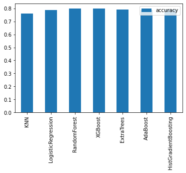

```python
model_compare = pd.DataFrame(model_scores, index=['accuracy'])
model_compare.T.plot.bar();
```

# Evaluate the longer running models

## Logistic Regression (can also be used as a classifier)

https://scikit-learn.org/stable/modules/generated/sklearn.linear_model.LogisticRegression.html

```python
lr_grid = {"C":np.logspace(-4, 4, 20),
           "solver":["liblinear"]}
```

## RandomForestClassifier

https://scikit-learn.org/stable/modules/generated/sklearn.ensemble.RandomForestClassifier.html

```python
# From: https://blog.dataiku.com/narrowing-the-search-which-hyperparameters-really-matter
#     Order of importance:
#     1. Min Samples Leaf (1 - 60)
#     2. Max Features: (0.1 - 1.0)
#     3. Max Depth: (6 - 20)
#     4. Number of Estimators: (10 - 200)

rf_grid = {"min_samples_leaf":np.arange(1, 60, 2),
           "max_features":np.arange(0.1, 1.0, 0.2),
           "max_depth":np.arange(5, 20, 1),
           "n_estimators":np.arange(10, 200, 5),
           "n_jobs":[-1]
          }
```

## XGBoostClassifier

https://xgboost.readthedocs.io/en/stable/parameter.html

```python
# Narrowing parameter articles:

# https://xgboost.readthedocs.io/en/stable/tutorials/param_tuning.html
# https://blog.dataiku.com/narrowing-the-search-which-hyperparameters-really-matter

xgb_grid = {"max_depth": np.arange(3, 18, 6),
            "gamma": [1, 9],
            "reg_alpha": np.arange(40, 180, 60),
            "reg_lambda": [0, 1],
            "colsample_bytree": [0.5, 1],
            "min_child_weight": [0, 5, 1],
            "n_estimators": [180],
            "eta": np.arange(0.2, 1.0, 0.2),
            "subsample": [0.8, 0.9, 1.0],
            "objective": ['binary:logistic'],
            "seed": [42],
            "use_label_encoder": [False]
           }
```

## ExtraTreesClassifier

https://scikit-learn.org/stable/modules/generated/sklearn.ensemble.ExtraTreesClassifier.html#sklearn.ensemble.ExtraTreesClassifier

```python
et_grid = {"min_samples_leaf":np.arange(1, 60, 2),
           "max_features":np.arange(0.1, 1.0, 0.2),
           "max_depth":np.arange(5, 20, 5),
           "n_estimators":np.arange(10, 200, 10),
           "n_jobs":[-1]
          }
```

## AdaBoostClassifier

https://scikit-learn.org/stable/modules/generated/sklearn.ensemble.AdaBoostClassifier.html#sklearn.ensemble.AdaBoostClassifier

```python
# Hyperparameter tuning article:
# https://www.kaggle.com/code/juanmah/tactic-03-hyperparameter-optimization-adaboost

ab_grid = {'n_estimators': np.arange(1, 100, 2),
           'learning_rate': [(0.97 + x / 100) for x in range(0, 8)],
           'algorithm': ['SAMME', 'SAMME.R']
          }
```

## HistGradientBoostingClassifier

https://scikit-learn.org/stable/modules/generated/sklearn.ensemble.HistGradientBoostingClassifier.html#sklearn.ensemble.HistGradientBoostingClassifier

```python
# hgb_grid = {'learning_rate': (0.01, 0.1, 1, 10), # default is 0.1
#             'max_leaf_nodes': (3, 10, 30), # default is 31, min is 2
#             'max_bins': np.arange(50, 200, 2)
#            }
# .90 AUC and 0.80710 on Kaggle, also got rid of all value normalization
#{'learning_rate': 0.1, 'max_bins': 188, 'max_leaf_nodes': 10}

# hgb_grid = {'learning_rate': [0.01], # default is 0.1
#             'max_leaf_nodes': [10], # default is 31
#             'max_bins': [188],
#            }

hgb_grid = {'learning_rate': np.arange(.001, 1, .01), # default is 0.1
            'max_leaf_nodes': np.arange(6, 50, 2), # default is 31, min is 2
            'max_bins': np.arange(50, 300, 25)
           }
```

## Setup the specific model parameters

```python
if RUN_LR_RANDOM:
    model = RandomizedSearchCV(LogisticRegression(),
                               param_distributions=lr_grid,
                               cv=5,
                               n_iter=20,
                               n_jobs=-1,
                               verbose=True)
    clf = LogisticRegression()
    MODEL_SUFFIX = "lr"
```

```python
if RUN_LR_GRID:
    model = GridSearchCV(LogisticRegression(),
                         param_grid=lr_grid,
                         cv=5,
                         n_jobs=-1,
                         verbose=True)
    clf = LogisticRegression()
    MODEL_SUFFIX = "lr"
```

```python
if RUN_RF_RANDOM:
    model = RandomizedSearchCV(RandomForestClassifier(),
                               param_distributions=rf_grid,
                               cv=5,
                               n_iter=5,
                               n_jobs=-1,
                               verbose=True)
    clf = RandomForestClassifier()
    MODEL_SUFFIX = "rf"
```

```python
if RUN_RF_GRID:
    model = GridSearchCV(RandomForestClassifier(),
                         param_grid=rf_grid,
                         cv=2,
                         n_jobs=-1,
                         verbose=True)
    clf = RandomForestClassifier()
    MODEL_SUFFIX = "rf"
```

```python
if RUN_XGB_RANDOM:
    model = RandomizedSearchCV(xgb.XGBClassifier(),
                               param_distributions=xgb_grid,
                               cv=5,
                               n_iter=5,
                               n_jobs=-1,
                               verbose=True)
    clf = xgb.XGBClassifier()
    MODEL_SUFFIX = "xgb"
```

```python
if RUN_XGB_GRID:
    model = GridSearchCV(xgb.XGBClassifier(),
                         param_grid=xgb_grid,
                         cv=2,
                         n_jobs=-1,
                         verbose=True)
    clf = xgb.XGBClassifier()
    MODEL_SUFFIX = "xgb"
```

```python
if RUN_ET_RANDOM:
    model = RandomizedSearchCV(ExtraTreesClassifier(),
                               param_distributions=et_grid,
                               cv=5,
                               n_iter=5,
                               n_jobs=-1,
                               verbose=True)
    clf = ExtraTreesClassifier()
    MODEL_SUFFIX = "et"
```

```python
if RUN_ET_GRID:
    model = GridSearchCV(ExtraTreesClassifier(),
                         param_grid=et_grid,
                         cv=2,
                         n_jobs=-1,
                         verbose=True)
    clf = ExtraTreesClassifier()
    MODEL_SUFFIX = "et"
```

```python
if RUN_AB_RANDOM:
    model = RandomizedSearchCV(AdaBoostClassifier(),
                               param_distributions=ab_grid,
                               cv=5,
                               n_iter=5,
                               n_jobs=-1,
                               verbose=True)
    clf = AdaBoostClassifier()
    MODEL_SUFFIX = "ab"
```

```python
if RUN_AB_GRID:
    model = GridSearchCV(AdaBoostClassifier(),
                         param_grid=ab_grid,
                         cv=2,
                         n_jobs=-1,
                         verbose=True)
    clf = AdaBoostClassifier()
    MODEL_SUFFIX = "ab"
```

```python
if RUN_HGB_RANDOM:
    model = RandomizedSearchCV(HistGradientBoostingClassifier(),
                               param_distributions=hgb_grid,
                               cv=5,
                               n_iter=20,
                               n_jobs=-1,
                               verbose=True)
    clf = HistGradientBoostingClassifier()
    MODEL_SUFFIX = "hgb"
```

```python
if RUN_HGB_GRID:
    model = GridSearchCV(HistGradientBoostingClassifier(),
                         param_grid=hgb_grid,
                         cv=2,
                         n_jobs=-1,
                         verbose=True)
    clf = HistGradientBoostingClassifier()
    MODEL_SUFFIX = "hgb"
```

> The 'cv' values stands for Cross Validation. The training and validation data is again split into training and test sets. The value of cv signifies how many cross validations will occur. In the picture below, a cv value 5 ensures that 20% of the data is used to test the newly split training data and is picked from the entire data set (e.g., 5 subsets of 20% each).

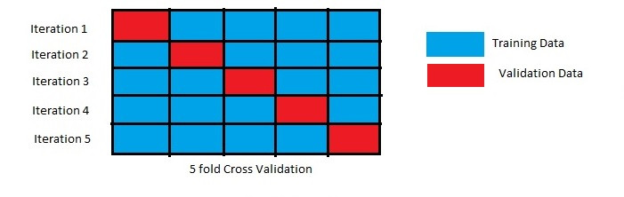

## Fit the Model

```python
start = timer()

if RUN_XGB_RANDOM or RUN_XGB_GRID: # add eval_metric to silence warnings
    model.fit(X_train, y_train, eval_metric='rmse');
else:
    model.fit(X_train, y_train);

end = timer()
print("Execution time HH:MM:SS:", timedelta(seconds=end-start))
```

```
Fitting 2 folds for each of 22000 candidates, totalling 44000 fits
```

```
Execution time HH:MM:SS: 0:24:08.251253
```

## Begin evaluating the results

```python
print(model.score(X_test, y_test))
```

```
0.8050603795284647
```

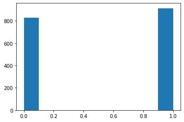

```python
y_preds = model.predict(X_test)
plt.hist(y_preds)
```

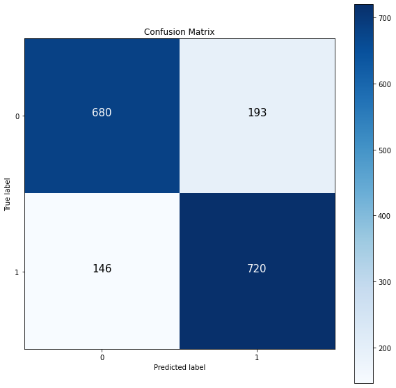

```python
make_confusion_matrix(y_test, y_preds)
```

```python
print(classification_report(y_test, y_preds, target_names=['Not Transported', 'Transported']))
```

[output not shown]

## Instantiate a new model (classifier) with the best parameters and continue evaluation

```python
# What did the search find for the best parameters?
print(model.best_params_)
```

```
{'learning_rate': 0.12099999999999998, 'max_bins': 175, 'max_leaf_nodes': 8}
```

```python
clf.set_params(**model.best_params_)
```

```
HistGradientBoostingClassifier(learning_rate=0.12099999999999998, max_bins=175,
                               max_leaf_nodes=8)
```

> Classification accuracy is our starting point. It is the number of correct predictions made divided by the total number of predictions made, multiplied by 100 to turn it into a percentage.

> Accuracy can be misleading. Sometimes it may be desirable to select a model with a lower accuracy because it has a greater predictive power on the problem.

> For example, in a problem where there is a large class imbalance, a model can predict the value of the majority class for all predictions and achieve a high classification accuracy, the problem is that this model is not useful in the problem domain. This is called the Accuracy Paradox. For problems like, this additional measures are required to evaluate a classifier.

```python
# Cross-validated accuracy score
cv_acc = cross_val_score(clf,
                         X,
                         y,
                         n_jobs=-1,
                         cv=5, # 5-fold cross-validation
                         scoring="accuracy") # accuracy as scoring
cv_acc
```

```
array([0.76020702, 0.78780909, 0.79873491, 0.8273878 , 0.79804373])
```

```python
# Since there are 5 metrics here (one for each 'fold' when cv = 5), we'll take the average.
cv_acc = np.mean(cv_acc)
cv_acc
```

```
0.7944365073640591
```

> Precision is the number of True Positives divided by the number of True Positives and False Positives. In other words, it is the number of positive predictions divided by the total number of positive class values predicted. It is also called the Positive Predictive Value (PPV).

```python
cv_precision = np.mean(cross_val_score(clf,
                                       X,
                                       y,
                                       n_jobs=-1,
                                       cv=5, # 5-fold cross-validation
                                       scoring="precision")) # precision as scoring
cv_precision
```

```
0.8147954197325404
```

> Recall is the number of True Positives divided by the number of True Positives and the number of False Negatives. In other words, it is the number of positive predictions divided by the number of positive class values in the test data. It is also called Sensitivity or the True Positive Rate.

> Recall can be thought of as a measure of a classifiers completeness. A low recall indicates many False Negatives.

```python
# Cross-validated recall score
cv_recall = np.mean(cross_val_score(clf,
                                    X,
                                    y,
                                    n_jobs=-1,
                                    cv=5, # 5-fold cross-validation
                                    scoring="recall")) # recall as scoring
cv_recall
```

```
0.7775394651011089
```

> The F1 Score is the 2*((precision**recall)/(precision+recall)). It is also called the F Score or the F Measure. The F1 score conveys the balance between the precision and the recall.

```python
# Cross-validated F1 score
cv_f1 = np.mean(cross_val_score(clf,
                                X,
                                y,
                                n_jobs=-1,
                                cv=5, # 5-fold cross-validation
                                scoring="f1")) # f1 as scoring
cv_f1
```

```
0.7888346895443641
```

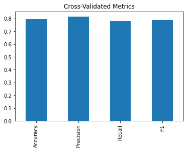

```python
# Visualizing cross-validated metrics
cv_metrics = pd.DataFrame({"Accuracy": cv_acc,
                           "Precision": cv_precision,
                           "Recall": cv_recall,
                           "F1": cv_f1},
                           index=[0])

cv_metrics.T.plot.bar(title="Cross-Validated Metrics", legend=False);
```

```python
# Fit an instance of the model (taken from above)
if RUN_XGB_RANDOM or RUN_XGB_GRID: # add eval_metric to silence warnings
    clf.fit(X_train, y_train, eval_metric='rmse');
else:
    clf.fit(X_train, y_train);
```

> The following image explains what you can interpret from a ROC Curve

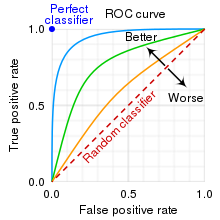

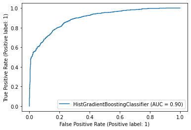

```python
RocCurveDisplay.from_estimator(clf,
                               X_test,
                               y_test);
```

```python
if RUN_LR_RANDOM or RUN_LR_GRID:
    print(clf.coef_)
```

```python
if RUN_LR_RANDOM or RUN_LR_GRID:
    # Match features to columns
    features_dict = dict(zip(processed_test_data.columns, list(clf.coef_[0])))
    features_dict
```

> Let's visualize feature importance. This is only available for the LogisticRegression model.

> In the Kaggle Space Titanic example, for each feature, a negative number means the person was less likely to be transported and a positive number means they were more likely to be transported. Numbers near zero mean that the feature had little or no impact on the person being transported.

> It is important to understand what a "positive" number means to your specific target (e.g. Transported) |value and what a "negative" number means to the specific target.

```python
if RUN_LR_RANDOM or RUN_LR_GRID:
    features_df = pd.DataFrame(features_dict, index=[0])
    features_df.T.plot.bar(title="Feature Importance", legend=False);
```

```python
prepare_kaggle_submission(clf, processed_test_data, test_data, MODEL_SUFFIX)
```

```
     PassengerId  Transported
0        0013_01         True
1        0018_01        False
2        0019_01         True
3        0021_01         True
4        0023_01         True
...          ...          ...
4272     9266_02         True
4273     9269_01        False
4274     9271_01         True
4275     9273_01         True
4276     9277_01         True

[4277 rows x 2 columns]
```